# AirQualityR

```python
import numpy as np
import pandas as pd
import matplotlib.pyplot as mat, mpld3
from IPython.display import display, Markdown
```

```python
outPath = '.\\reports\\'
```

```python
mat.rcParams['figure.figsize']=[6,4]
```

```python
def importTensorDF(df):
    df = df.rename(columns={"Date/Time":"time"})
    df['time'] = pd.to_datetime(df['time'],format="%d/%m/%Y %H:%M:%S")
    df = df.set_index('time')
    df = df.interpolate(method='time',limit=15)
    df = df[~df.index.duplicated(keep='first')]
    df = df.asfreq('1Min',method='pad') #try normalize=True
    df = df.resample('1Min').mean()
    return df
```

```python
path = '.\\dataR\\'
rngStr = '14-10-2016_to_14-06-2017'
hcols = ['Unused','kitchenH','bedroomlux','livinglux','livingH','bathroomH','bedroomH','livingSound','livingVoc','livingCo2','bedroomCo2','bedroom2H','livingNH','bedroomNH','bedroom2NH','kitchenNH','bathroomNH']
```

```python
hdf = importTensorDF(pd.read_csv(path +'humidity_'+rngStr+'.csv'))
hdf.columns = hcols
rooms = [c for c in hcols if "Co2" in c]
hdf = hdf[rooms]*100 #data is stored /100
print "[+] Data imported succesfully."
```

```
[+] Data imported succesfully.
```

## CO2 concentration

According to CIBSE, the indoor air quality, a part of indoor environment quality, may be estimated with concentration of contaminants that should not have negative impacts on occupants’ health and performance, such as CO2. ASHRAE standard derived by Pettenkorfer’s studies suggested a maximum CO2 level of 1000 ppm. More recently ASHRAE recommended a difference between indoor and outdoor concentration not more than 700 ppm. According to European standard EN 13779 indoor air quality is considered achieved with less than 400 ppm above the outdoor level, medium quality in the range between 400-600 ppm, moderate from 600 to 1000 ppm and low above 1000 ppm. The concentration of CO2 depends on human activities such as breathing and smoking, high occupancy and limited air change rates for the intake of fresh air. The high concentration of CO2 provokes loss of consciousness (fainting) and limited cognitive performance.

For this building, CO2 data is collected in the following rooms:

```python
rooms = [c for c in hcols if "Co2" in c]
display(Markdown('__'+', '.join([r.replace('Co2','').title() for r in rooms])+'__'))
```

**Living, Bedroom**

```python
#output widgets
r = mat.rcParams['figure.figsize']
mat.rcParams['figure.figsize']=[12,5]
for room in rooms:
    hdf[room]['20170401'].plot()
    mpld3.save_html(mat.gcf(), outPath+room.replace('Co2','')+'.html')

mat.close()
mat.rcParams['figure.figsize']=r
```

### Average CO2 Level Safety for this building:

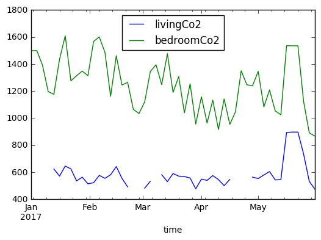

```python
hdf['2017'].resample('3D').mean().plot(); mat.show()
```

On average, the CO2 level for each room was was:

```python
standard = [{'max':350, 'name':'<div class="alert alert-block alert-info">Normal</div>', 'description':'Normal background concentration', 'action': 'None'},
           {'max':1000, 'name':'<div class="alert alert-block alert-info">Normal</div>', 'description':'Typical concentration in indoor environments', 'action': 'None'},
           {'max':2000, 'name':'<div class="alert alert-block alert-warning">Warning</div>', 'description':'Expected complaints of drowsiness and poor air quality', 'action': 'open windows'},
           {'max':5000, 'name':'<div class="alert alert-block alert-danger">Danger</div>', 'description':'Stale, stuffy air. Expect headaches, drowsiness, increased heart rates, and slight nausea. Eventual death of all exposed individuals.', 'action': 'open windows immediately'}]
```

```python
def co2_status(room):
    v = hdf[room].mean();
    for level in standard:
        if (v<level['max']): return level
```

```python
for room in rooms:
    status = co2_status(room)
    display(Markdown('### '+room.replace('Co2','').title()))
    #display(Markdown('__status:__ '))
    display(Markdown(status['name']))
    display(Markdown(status['description']))
    display(Markdown('__action:__ '+status['action']))
```

Living

Normal

Typical concentration in indoor environments

**action:** None

Bedroom

Warning

Expected complaints of drowsiness and poor air quality

**action:** open windows